# Problem Set 3

## Task 2

```python
import pandas as pd
import sqlite3
import matplotlib.pyplot as plt
import numpy as np
from plotnine import *
import seaborn as sns
```

```python
import warnings
warnings.filterwarnings('ignore')
```

```python
conn = sqlite3.connect("ps3_db.sqlite")
```

```python
#run sql query to order by n_bits
#(Note, as the plot displays the countries backwards, i order in ascending order, so they show up in descending order in the image)


query = '''

select
*
from country_level
order by country_level.n_bits

'''

x = pd.read_sql(query,conn)
```

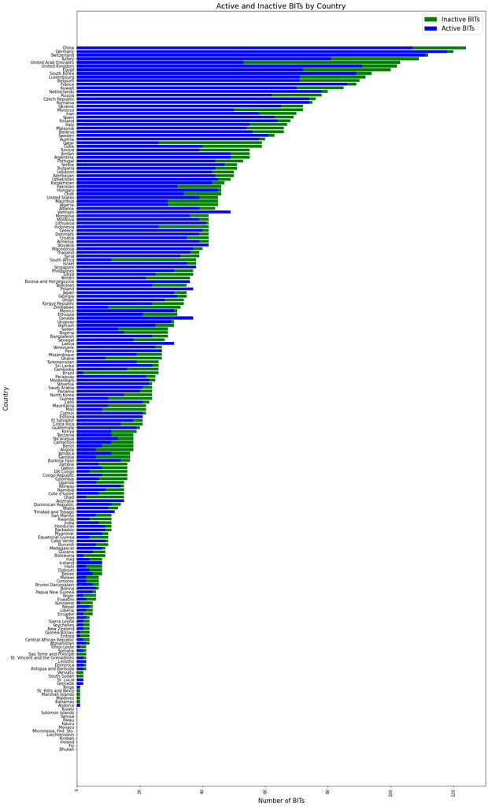

```python
#plot layered barcharts and save png file

plt.figure(figsize = (18, 35))

plt.barh(x.Name, x.n_bits, color='green', label = "Inactive BITs")
plt.barh(x.Name, x.n_bits_active, color='blue', label = "Active BITs")
plt.xticks(rotation = 90)
plt.xlabel("Number of BITs", fontsize = 15)
plt.ylabel("Country", fontsize = 15)
plt.title("Active and Inactive BITs by Country", fontsize = 18)
plt.legend(fontsize = 15)
plt.savefig("/Users/anandigupta/Downloads/Visualization 1.png", dpi=None, facecolor='w', edgecolor='w',
        orientation='portrait',
        transparent=False, bbox_inches=None, pad_inches=0.1,
        metadata=None)

plt.show()
```

```python
query = '''

-- create table that groups by year enforced and counts the instances in each year
--filter to active agreements only

with table1 as (select
year_enforced, count(status) as count_enforced
from dyad_level
where status = "active"
group by year_enforced),


-- create table that groups by year terminated and counts the instances in each year
--filter to terminated agreements only

table2 as (select
year_terminated, count(status) as count_terminated
from dyad_level
where status = "terminated"
group by year_terminated)


-- merge on year and calculate net new as difference between enforced and terminated
-- for years where terminated is NA replace net new with enforced

select a.year_enforced as year, a.count_enforced, b.count_terminated,
case when b.count_terminated is null then a.count_enforced
else (a.count_enforced - b.count_terminated) end as net_new
from table1 a left join table2 b on a.year_enforced = b.year_terminated

'''

y = pd.read_sql(query,conn)
```

```python
y.head()
```

|  | year | count_enforced | count_terminated | net_new |
| --- | --- | --- | --- | --- |
| 0 | 1962.0 | 6 | NaN | 6 |
| 1 | 1963.0 | 8 | NaN | 8 |
| 2 | 1964.0 | 12 | NaN | 12 |
| 3 | 1965.0 | 2 | NaN | 2 |
| 4 | 1966.0 | 16 | NaN | 16 |

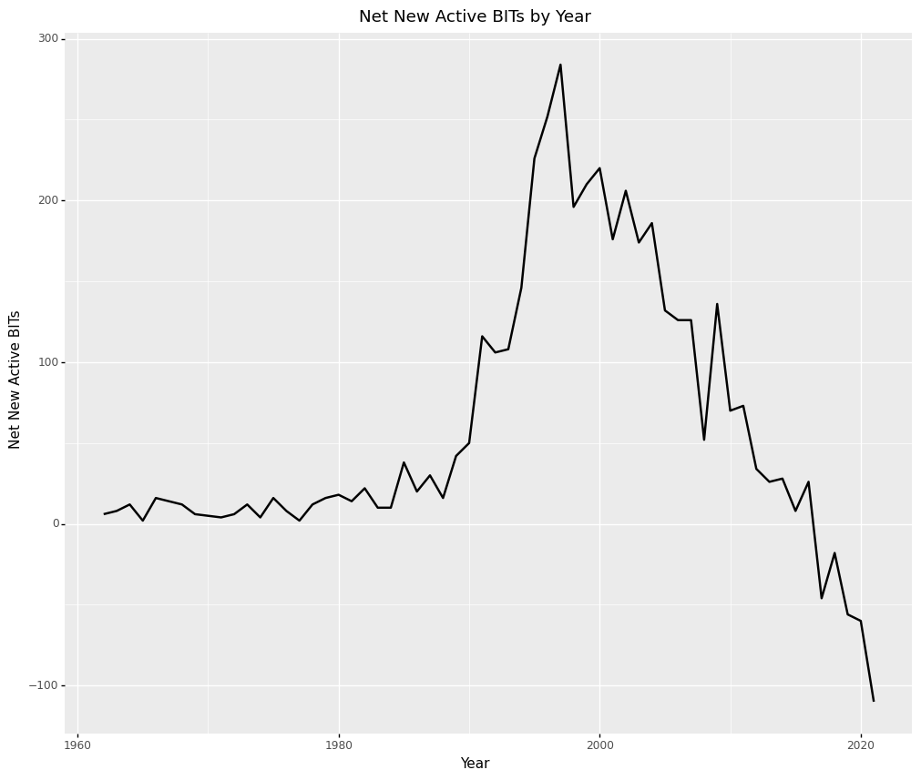

```python
#plot net new bits and save to png file

p2 = (
  ggplot(y,aes(x = "year",y='net_new')) +
  geom_path(size=1) + theme(figure_size = (12, 10), axis_text_x  = element_text(angle = 0, hjust = 0.5))
    + ggtitle("Net New Active BITs by Year")
    + labs(x = "Year", y = "Net New Active BITs")
)

ggsave(plot = p2, filename = "Visualization 2", path = "/Users/anandigupta/Downloads")

p2
```

```python
query = '''

-- Create table where country A is always not the country of interest
-- Country B is always the country of interest
-- active bits in place = 1 when one of the parties is a country of interest

select distinct country_A, country_B,
case when country_A in ("China", "United States", "Russia", "Germany") or country_B in ("China", "United States", "Russia", "Germany") then 1 else 0 end as active_BIT_in_place,
case when country_A in ("China", "United States", "Russia", "Germany") then country_B else country_A end as country,
case when country_A in ("China", "United States", "Russia", "Germany") then country_A else country_B end as country2
from dyad_level
where status = "active" and (country_B in ("China", "United States", "Russia", "Germany"))

'''
z = pd.read_sql(query,conn)
```

```python
z.head()
```

|  | country_A | country_B | active_BIT_in_place | country | country2 |
| --- | --- | --- | --- | --- | --- |
| 0 | Afghanistan | Germany | 1 | Afghanistan | Germany |
| 1 | Albania | Russia | 1 | Albania | Russia |
| 2 | Albania | United States | 1 | Albania | United States |
| 3 | Albania | China | 1 | Albania | China |
| 4 | Albania | Germany | 1 | Albania | Germany |

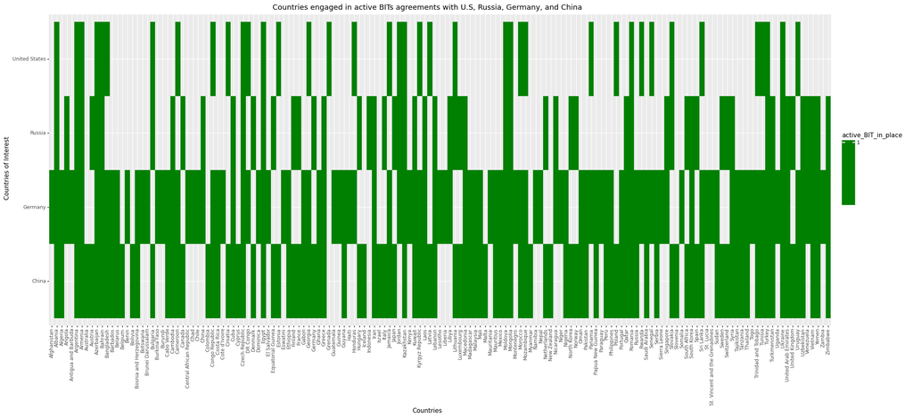

```python
#plot data and apply green fill for countries with active bits in place with us, china, russia or germany
#save plot

p3 = (
    ggplot(z, aes(x = "country", y = "country2", fill = "active_BIT_in_place"))+ geom_tile()
    + theme(figure_size = (25, 10), axis_text_x  = element_text(angle = 90, hjust = 0.5))
    +scale_fill_gradient(high="green")
    + labs(x = "Countries", y = "Countries of Interest")
    + ggtitle("Countries engaged in active BITs agreements with U.S, Russia, Germany, and China")

)

ggsave(plot = p3, filename = "Visualization 3", path = "/Users/anandigupta/Downloads")

p3
```

### Task 3

1) In general, countries with higher gdp per capita (such as Germany, Switzerland, and Luxembourg) have have more BITs than countries with lower GDP per capita (such as Somalia and Afghanistan). However, there are some exceptions such as Egypt, Morocco, and Malaysia, which have low GDP per capita but have a higher number of BITs. Regime type may be indicative of this as many of these "exceptions" have a history of monarchies.

2) The 1990s saw a sharp increase in the number of BITs entered into, as compared to the 1980s. This can in part be explained by the creation of new independent states after the dissolution of the soviet union in 1991 and as trade increased and developing countries began signing treaties with each other. In recent years (2000s and 2010s) the number of BITs agreements have been falling. In 2020, net BITs agreements for example, net new treaties were negative. This may in part be explained by the signing of an agreement in 2020 that terminated intra EU agreements.